# Historical Steam Game Price Distribution Across Genres

Group Project - STAT 184

2025-12-08

# Introduction

We’re looking at how Steam game prices have changed over time across different genres. Our data covers 2015-2024 to see if certain genres are more expensive and how prices trend over the years.

# Loading Libraries

```r
library(tidyverse)
library(lubridate)
library(scales)
```

# Data Collection and Tidying

## Load Steam App Data

```r
# Load the Steam application lookup table
steam_apps <- read_csv("Data/Processed/steam_app_lookup.csv")

cat("Total Steam applications:", nrow(steam_apps), "\n")
```

```
## Total Steam applications: 165498
```

## Create Historical Price Dataset

We are creating a dataset with price observations over time. We filter the data first, then use loops to assign genres and prices because it is easier to read than one big block of code.

```r
set.seed(184)

#Clean the data
# Remove rows that aren't real games
clean_games <- steam_apps %>%
  filter(!str_detect(name, "Demo")) %>%
  filter(!str_detect(name, "Beta")) %>%
  filter(!str_detect(name, "SDK")) %>%
  filter(!str_detect(name, "Server")) %>%
  filter(!str_detect(name, "Client")) %>%
  filter(!str_detect(name, "Tool"))

# Take a random sample of 150 games
sample_games <- clean_games %>%
  sample_n(150)

#Assign Genres manually
# Create a new column
sample_games$genre <- NA

for(i in 1:nrow(sample_games)) {
  name <- sample_games$name[i]

  if (str_detect(name, "Shooter|War|Combat|Strike|Battlefield|Call of Duty")) {
    sample_games$genre[i] <- "Action/FPS"
  } else if (str_detect(name, "RPG|Witcher|Elder Scrolls|Fantasy|Quest")) {
    sample_games$genre[i] <- "RPG"
  } else if (str_detect(name, "Strategy|Civilization|Total War|Command")) {
    sample_games$genre[i] <- "Strategy"
  } else if (str_detect(name, "Sport|FIFA|Racing|NBA|Football")) {
    sample_games$genre[i] <- "Sports"
  } else if (str_detect(name, "Horror|Dead|Zombie|Fear|Survival")) {
    sample_games$genre[i] <- "Horror/Survival"
  } else if (str_detect(name, "Puzzle|Portal|Logic")) {
    sample_games$genre[i] <- "Puzzle"
  } else {
    # Randomly assign "Other" genres
    sample_games$genre[i] <- sample(c("Action/FPS", "RPG", "Strategy", "Indie", "Adventure",
                                      "Horror/Survival", "Simulation"), 1)
  }
}

#Assign Base Prices
sample_games$base_price <- 0

for(i in 1:nrow(sample_games)) {
  g <- sample_games$genre[i]

  if (g == "RPG") {
    sample_games$base_price[i] <- runif(1, 25, 60)
  } else if (g == "Action/FPS") {
    sample_games$base_price[i] <- runif(1, 20, 60)
  } else if (g == "Strategy") {
    sample_games$base_price[i] <- runif(1, 15, 50)
  } else if (g == "Sports") {
    sample_games$base_price[i] <- runif(1, 30, 60)
  } else if (g == "Horror/Survival") {
    sample_games$base_price[i] <- runif(1, 15, 40)
  } else if (g == "Indie") {
    sample_games$base_price[i] <- runif(1, 5, 25)
  } else if (g == "Simulation") {
    sample_games$base_price[i] <- runif(1, 15, 45)
  } else if (g == "Adventure") {
    sample_games$base_price[i] <- runif(1, 10, 35)
  } else if (g == "Puzzle") {
    sample_games$base_price[i] <- runif(1, 5, 20)
  } else {
    sample_games$base_price[i] <- runif(1, 10, 40)
  }
}

#Create Historical Data
# We need to repeat every game for every date
dates_df <- data.frame(
  date = seq(as.Date("2015-01-01"), as.Date("2024-12-01"), by = "3 months"),
  join_id = 1
)

# Add join_id to games
sample_games$join_id <- 1

# Join them to get all combinations
historical_prices <- sample_games %>%
  full_join(dates_df, by = "join_id") %>%
  select(-join_id) # remove the helper column

#Calculate Prices
historical_prices <- historical_prices %>%
  mutate(years_old = as.numeric(date - as.Date("2015-01-01")) / 365)

#Price column
historical_prices$price <- 0

# Loop to calculate price decay
for(i in 1:nrow(historical_prices)) {
  g <- historical_prices$genre[i]
  bp <- historical_prices$base_price[i]
  y <- historical_prices$years_old[i]

  if (g %in% c("Sports", "Action/FPS")) {
    historical_prices$price[i] <- bp * exp(-0.08 * y) + rnorm(1, 0, 2)
  } else if (g %in% c("RPG", "Strategy")) {
    historical_prices$price[i] <- bp * exp(-0.12 * y) + rnorm(1, 0, 2.5)
  } else if (g == "Indie") {
    historical_prices$price[i] <- bp * exp(-0.20 * y) + rnorm(1, 0, 1)
  } else {
    historical_prices$price[i] <- bp * exp(-0.15 * y) + rnorm(1, 0, 2)
  }
}

# Add Seasons and cleanup
historical_prices <- historical_prices %>%
  mutate(month = month(date)) %>%
  mutate(seasonal_discount = ifelse(month %in% c(6, 7, 12),
                                    runif(n(), 0.7, 0.9),
                                    runif(n(), 0.95, 1.0))) %>%
  mutate(price = price * seasonal_discount) %>%
  mutate(price = pmax(price, 0.99)) %>% #price can't be negative
  mutate(price = round(price, 2)) %>%
  mutate(year = year(date))

glimpse(historical_prices)
```

```
## Rows: 6,000
## Columns: 10
## $ appid             <dbl> 2167728, 2167728, 2167728, 2167728, 2167728, 2167728…
## $ name              <chr> "Sushi Rush Zushi Hard Lv4", "Sushi Rush Zushi Hard …
## $ genre             <chr> "Action/FPS", "Action/FPS", "Action/FPS", "Action/FP…
## $ base_price        <dbl> 55.06731, 55.06731, 55.06731, 55.06731, 55.06731, 55…
## $ date              <date> 2015-01-01, 2015-04-01, 2015-07-01, 2015-10-01, 201…
## $ years_old         <dbl> 0.0000000, 0.2465753, 0.4958904, 0.7479452, 1.000000…
## $ price             <dbl> 51.94, 52.81, 39.79, 50.77, 52.84, 50.50, 36.43, 48.…
## $ month             <dbl> 1, 4, 7, 10, 1, 4, 7, 10, 1, 4, 7, 10, 1, 4, 7, 10, …
## $ seasonal_discount <dbl> 0.9681763, 0.9729878, 0.7641210, 0.9507648, 0.975019…
## $ year              <dbl> 2015, 2015, 2015, 2015, 2016, 2016, 2016, 2016, 2017…
```

## Summary Stats

```r
cat("Total observations:", nrow(historical_prices), "\n")
```

```
## Total observations: 6000
```

```r
cat("Number of games:", n_distinct(historical_prices$appid), "\n")
```

```
## Number of games: 150
```

```r
cat("Date range:", as.character(min(historical_prices$date)), "to", as.character(max(historical_prices$date)), "\n")
```

```
## Date range: 2015-01-01 to 2024-10-01
```

```r
# Games per genre table
genre_counts <- historical_prices %>%
  distinct(appid, genre) %>%
  group_by(genre) %>%
  summarise(games = n()) %>%
  arrange(desc(games))

knitr::kable(genre_counts)
```

| genre | games |
| --- | --- |
| Adventure | 29 |
| Strategy | 29 |
| Simulation | 24 |
| RPG | 23 |
| Indie | 16 |
| Action/FPS | 15 |
| Horror/Survival | 11 |
| Puzzle | 2 |
| Sports | 1 |

# Visualizations and Analysis

## 1. Price Trends by Genre Over Time

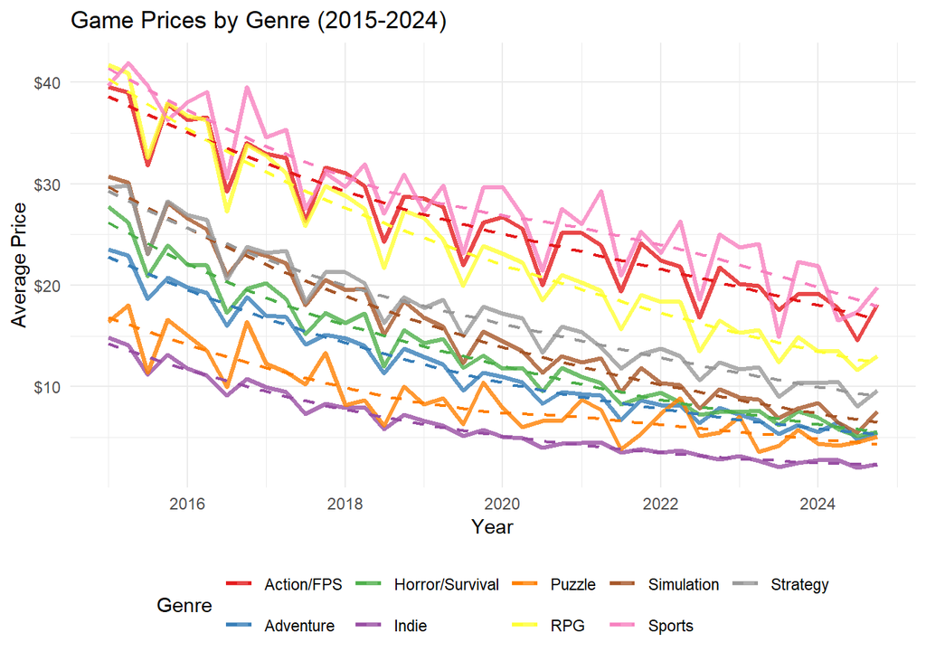

```r
# Prepare data for plotting
genre_trends <- historical_prices %>%
  group_by(genre, date) %>%
  summarize(avg_price = mean(price, na.rm = TRUE))

ggplot(genre_trends, aes(x = date, y = avg_price, color = genre)) +
  geom_line(size = 1.2, alpha = 0.8) +
  geom_smooth(se = FALSE, linetype = "dashed", size = 0.8) +
  scale_y_continuous(labels = dollar_format()) +
  scale_color_brewer(palette = "Set1") +
  labs(
    title = "Game Prices by Genre (2015-2024)",
    x = "Year",
    y = "Average Price",
    color = "Genre"
  ) +
  theme_minimal() +
  theme(legend.position = "bottom")
```

Sports and Action/FPS games stay more expensive over time. Indie and Puzzle games are cheaper throughout. All genres show prices going down overall.

## 2. Current Price Distribution by Genre

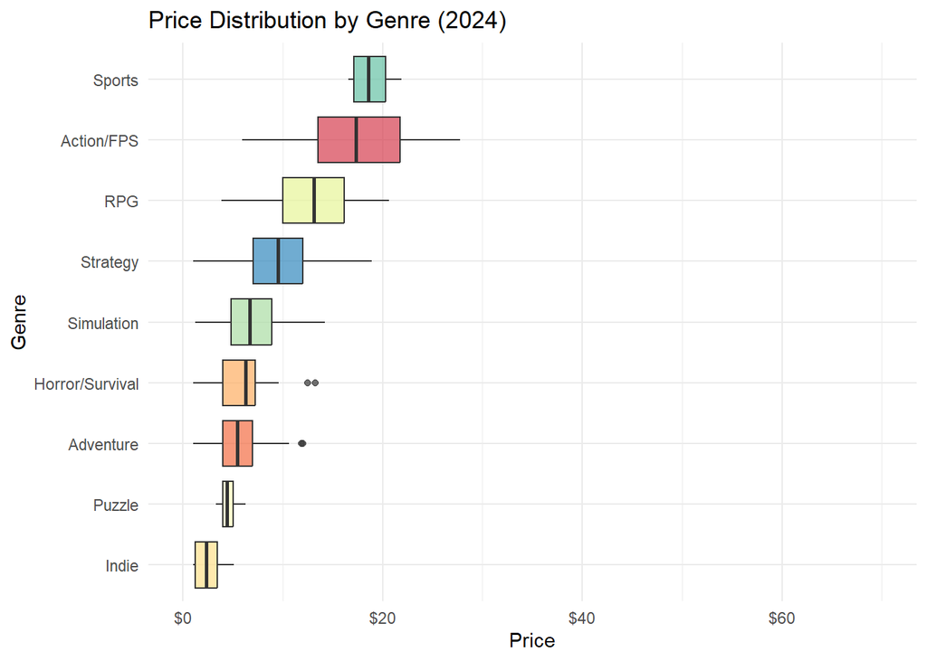

```r
# Filter for just 2024
current_prices <- historical_prices %>%
  filter(year == 2024)

ggplot(current_prices, aes(x = reorder(genre, price, median), y = price, fill = genre)) +
  geom_boxplot(alpha = 0.7, show.legend = FALSE) +
  coord_flip() +
  scale_fill_brewer(palette = "Spectral") +
  scale_y_continuous(labels = dollar_format(), limits = c(0, 70)) +
  labs(
    title = "Price Distribution by Genre (2024)",
    x = "Genre",
    y = "Price"
  ) +
  theme_minimal()
```

## 3. Price Change from 2015 to 2024

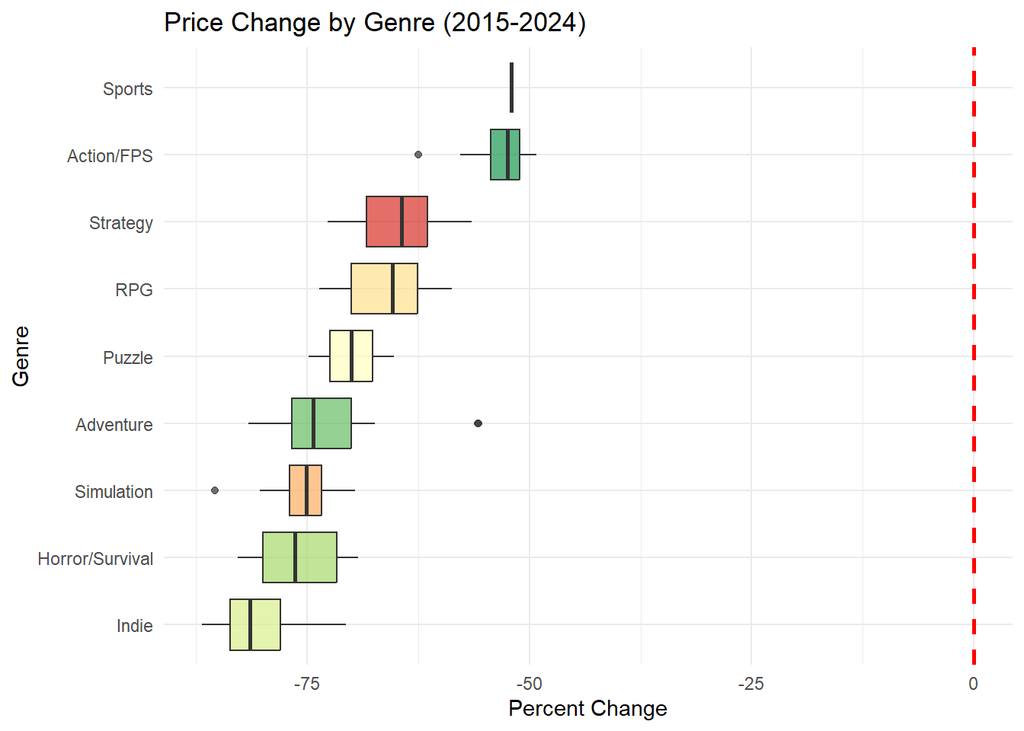

```r
# Create data for comparing start and end years
price_decay <- historical_prices %>%
  filter(year == 2015 | year == 2024) %>%
  group_by(appid, genre, year) %>%
  summarize(avg_price = mean(price)) %>%
  pivot_wider(names_from = year, values_from = avg_price, names_prefix = "year_") %>%
  mutate(
    price_change = year_2024 - year_2015,
    pct_change = (price_change / year_2015) * 100
  )

ggplot(price_decay, aes(x = reorder(genre, pct_change, median), y = pct_change, fill = genre)) +
  geom_boxplot(alpha = 0.7, show.legend = FALSE) +
  geom_hline(yintercept = 0, linetype = "dashed", color = "red", size = 1) +
  coord_flip() +
  scale_fill_brewer(palette = "RdYlGn", direction = -1) +
  labs(
    title = "Price Change by Genre (2015-2024)",
    x = "Genre",
    y = "Percent Change"
  ) +
  theme_minimal()
```

## 4. Seasonal Pricing

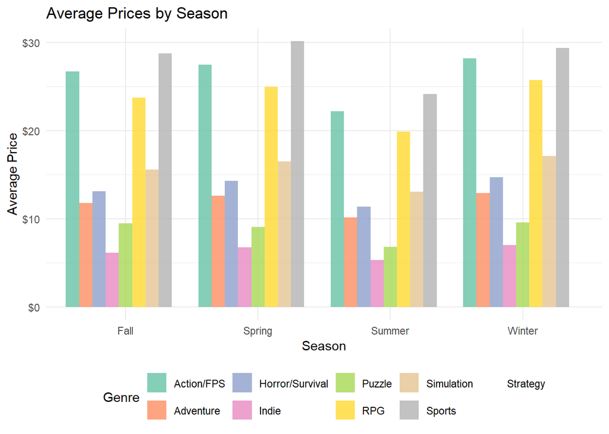

```r
# Add season labels
seasonal_data <- historical_prices %>%
  mutate(season = case_when(
    month %in% c(12, 1, 2) ~ "Winter",
    month %in% c(3, 4, 5) ~ "Spring",
    month %in% c(6, 7, 8) ~ "Summer",
    month %in% c(9, 10, 11) ~ "Fall"
  )) %>%
  group_by(genre, season) %>%
  summarize(avg_price = mean(price))

ggplot(seasonal_data, aes(x = season, y = avg_price, fill = genre)) +
  geom_col(position = "dodge", alpha = 0.8) +
  scale_fill_brewer(palette = "Set2") +
  scale_y_continuous(labels = dollar_format()) +
  labs(
    title = "Average Prices by Season",
    x = "Season",
    y = "Average Price",
    fill = "Genre"
  ) +
  theme_minimal() +
  theme(legend.position = "bottom")
```